# Chr18 SNP Analysis

Dave Speca

6/14/2017

```r
library(ggplot2)
library(dplyr)
```

### Read in the vcf file and add headers of Chr18.all.vcf:

```r
# read in .vcf file
Chr18.data <- read.table("Chr18.all.vcf", as.is=TRUE, na.strings=".")
vcf.header <- system("grep '#C' Chr18.all.vcf",intern = TRUE)
vcf.header <- sub("#","",vcf.header) #get rid of the pound sign
vcf.header <- unlist(strsplit(vcf.header,split="\t"))
colnames(Chr18.data) <- vcf.header
head(Chr18.data, 3)
```

```
##   CHROM     POS ID                REF                    ALT      QUAL
## 1 chr18 3000211 NA                  A                      G 87.699300
## 2 chr18 3000271 NA                  A                      G  1.499270
## 3 chr18 3000281 NA TTTTGTTTGTTTGTTTGT TTTTGTTTGTTTGTTTGTTTGT  0.146981
##   FILTER
## 1     NA
## 2     NA
## 3     NA
##                                                                                                                                                                                                                                                                                                          …
## 1                  AB=0.5;ABP=3.0103;AC=3;AF=0.75;AN=4;AO=5;CIGAR=1X;DP=6;DPB=6;DPRA=0;EPP=3.44459;EPPR=5.18177;GTI=0;LEN=1;MEANALT=1;MQM=55;MQMR=60;NS=2;NUMALT=1;ODDS=1.6879;PAIRED=1;PAIREDR=1;PAO=0;PQA=0;PQR=0;PRO=0;QA=144;QR=37;RO=1;RPL=1;RPP=6.91895;RPPR=5.18177;RPR=4;RUN=1;SAF=4;SAP=6.91895;…
## 2              AB=0.5;ABP=3.0103;AC=2;AF=0.5;AN=4;AO=4;CIGAR=1X;DP=8;DPB=8;DPRA=0;EPP=3.0103;EPPR=5.18177;GTI=1;LEN=1;MEANALT=1;MQM=19.75;MQMR=58.75;NS=2;NUMALT=1;ODDS=1.47135;PAIRED=1;PAIREDR=1;PAO=0;PQA=0;PQR=0;PRO=0;QA=135;QR=87;RO=4;RPL=0;RPP=11.6962;RPPR=11.6962;RPR=4;RUN=1;SAF=2;SAP=3.0103;…
## 3 AB=0.5;ABP=3.0103;AC=2;AF=0.5;AN=4;AO=4;CIGAR=1M4I17M;DP=8;DPB=10.5556;DPRA=0;EPP=3.0103;EPPR=5.18177;GTI=1;LEN=4;MEANALT=1;MQM=19.75;MQMR=58.75;NS=2;NUMALT=1;ODDS=3.37002;PAIRED=1;PAIREDR=1;PAO=1;PQA=37;PQR=37;PRO=1;QA=76;QR=152;RO=4;RPL=0;RPP=11.6962;RPPR=11.6962;RPR=4;RUN=1;SAF=2;SAP=3.0103;…
##                    FORMAT                                       DBA
## 1 GT:DP:AD:RO:QR:AO:QA:GL   1/1:4:0,4:0:0:4:103:-9.52543,-1.20412,0
## 2 GT:DP:AD:RO:QR:AO:QA:GL    0/1:6:3,3:3:46:3:94:-1.7322,0,-2.48708
## 3 GT:DP:AD:RO:QR:AO:QA:GL 0/1:6:3,3:3:111:3:39:-0.474718,0,-7.94468
##                                     Chr18
## 1 0/1:2:1,1:1:37:1:41:-3.48099,0,-3.09577
## 2 0/1:2:1,1:1:41:1:41:-3.14406,0,-3.48099
## 3 0/1:2:1,1:1:41:1:37:-2.31947,0,-2.87893
```

### String split data

```r
# Before splitting add NAs to blank cells

Chr18.data$DBA[is.na(Chr18.data$DBA)] <- "NA:NA:NA:NA:NA:NA:NA:NA"

DBA.tmp <- matrix(
  unlist(strsplit(Chr18.data$DBA,split = ":")),
  nrow=nrow(Chr18.data),
  byrow=TRUE
  )
head(DBA.tmp)
```

```
##      [,1]  [,2] [,3]  [,4] [,5]  [,6] [,7]  [,8]
## [1,] "1/1" "4"  "0,4" "0"  "0"   "4"  "103" "-9.52543,-1.20412,0"
## [2,] "0/1" "6"  "3,3" "3"  "46"  "3"  "94"  "-1.7322,0,-2.48708"
## [3,] "0/1" "6"  "3,3" "3"  "111" "3"  "39"  "-0.474718,0,-7.94468"
## [4,] "0/1" "10" "4,6" "4"  "98"  "6"  "187" "-5.852,0,-5.8895"
## [5,] "0/1" "11" "5,6" "5"  "106" "6"  "196" "-5.81838,0,-6.43519"
## [6,] "0/1" "9"  "3,6" "3"  "95"  "6"  "204" "-6.33152,0,-5.9801"
```

```r
colnames(DBA.tmp) <- paste("DBA",c("gt","tot.depth","NObsAllele", "ref.depth","ref.qual","alt.depth","alt.qual","gen.lik"),sep="_")

Chr18.data$Chr18[is.na(Chr18.data$Chr18)] <- "NA:NA:NA:NA:NA:NA:NA:NA"

Chr18.tmp <- matrix(
  unlist(strsplit(Chr18.data$Chr18,split = ":")),
  nrow=nrow(Chr18.data),
  byrow=TRUE
  )
head(Chr18.tmp)
```

```
##      [,1]  [,2] [,3]  [,4] [,5]  [,6] [,7] [,8]
## [1,] "0/1" "2"  "1,1" "1"  "37"  "1"  "41" "-3.48099,0,-3.09577"
## [2,] "0/1" "2"  "1,1" "1"  "41"  "1"  "41" "-3.14406,0,-3.48099"
## [3,] "0/1" "2"  "1,1" "1"  "41"  "1"  "37" "-2.31947,0,-2.87893"
## [4,] "0/1" "4"  "3,1" "3"  "119" "1"  "41" "-2.542,0,-8.38775"
## [5,] "0/1" "5"  "4,1" "4"  "143" "1"  "41" "-2.24097,0,-10.2173"
## [6,] "0/1" "6"  "5,1" "5"  "201" "1"  "41" "-1.93994,0,-13.5856"
```

```r
colnames(Chr18.tmp) <- paste("Chr18",c("gt","tot.depth","NObsAllele", "ref.depth","ref.qual","alt.depth","alt.qual","gen.lik"),sep="_")

Chr18.data <- cbind(Chr18.data,DBA.tmp,Chr18.tmp,stringsAsFactors=FALSE)
summary(Chr18.data)
```

```
##     CHROM                POS              ID              REF
##  Length:45487       Min.   : 3000211   Mode:logical   Length:45487
##  Class :character   1st Qu.:31737802   NA's:45487     Class :character
##  Mode  :character   Median :46565950                  Mode  :character
##                     Mean   :47544774
##                     3rd Qu.:67713256
##                     Max.   :90602578
##      ALT                 QUAL           FILTER            INFO
##  Length:45487       Min.   :    0.00   Mode:logical   Length:45487
##  Class :character   1st Qu.:   22.99   NA's:45487     Class :character
##  Mode  :character   Median :   64.36                  Mode  :character
##                     Mean   :  457.15
##                     3rd Qu.:  127.27
##                     Max.   :71330.70
##     FORMAT              DBA               Chr18
##  Length:45487       Length:45487       Length:45487
##  Class :character   Class :character   Class :character
##  Mode  :character   Mode  :character   Mode  :character
##
##
##
##     DBA_gt          DBA_tot.depth      DBA_NObsAllele
##  Length:45487       Length:45487       Length:45487
##  Class :character   Class :character   Class :character
##  Mode  :character   Mode  :character   Mode  :character
##
##
##
##  DBA_ref.depth      DBA_ref.qual       DBA_alt.depth
##  Length:45487       Length:45487       Length:45487
##  Class :character   Class :character   Class :character
##  Mode  :character   Mode  :character   Mode  :character
##
##
##
##  DBA_alt.qual       DBA_gen.lik          Chr18_gt
##  Length:45487       Length:45487       Length:45487
##  Class :character   Class :character   Class :character
##  Mode  :character   Mode  :character   Mode  :character
##
```

[output cut: 8 more lines]

```
##
##  Chr18_ref.qual     Chr18_alt.depth    Chr18_alt.qual
##  Length:45487       Length:45487       Length:45487
##  Class :character   Class :character   Class :character
##  Mode  :character   Mode  :character   Mode  :character
##
##
##
##  Chr18_gen.lik
##  Length:45487
##  Class :character
##  Mode  :character
##
##
##
```

### Convert columns back to numeric:

```r
Chr18.data[,c("DBA_tot.depth","DBA_ref.depth","DBA_ref.qual","DBA_alt.depth","DBA_alt.qual",
            "Chr18_tot.depth","Chr18_ref.depth","Chr18_ref.qual","Chr18_alt.depth","Chr18_alt.qual")] <-
  apply(Chr18.data[,c("DBA_tot.depth","DBA_ref.depth","DBA_ref.qual","DBA_alt.depth","DBA_alt.qual",
            "Chr18_tot.depth","Chr18_ref.depth","Chr18_ref.qual","Chr18_alt.depth","Chr18_alt.qual")],
        2,
        as.numeric
        )
head(Chr18.data, 4)
```

```
##   CHROM     POS ID                REF                    ALT      QUAL
## 1 chr18 3000211 NA                  A                      G 87.699300
## 2 chr18 3000271 NA                  A                      G  1.499270
## 3 chr18 3000281 NA TTTTGTTTGTTTGTTTGT TTTTGTTTGTTTGTTTGTTTGT  0.146981
## 4 chr18 3000323 NA                  A                      G 30.729600
##   FILTER
## 1     NA
## 2     NA
## 3     NA
## 4     NA
##                                                                                                                                                                                                                                                                                                          …
## 1                  AB=0.5;ABP=3.0103;AC=3;AF=0.75;AN=4;AO=5;CIGAR=1X;DP=6;DPB=6;DPRA=0;EPP=3.44459;EPPR=5.18177;GTI=0;LEN=1;MEANALT=1;MQM=55;MQMR=60;NS=2;NUMALT=1;ODDS=1.6879;PAIRED=1;PAIREDR=1;PAO=0;PQA=0;PQR=0;PRO=0;QA=144;QR=37;RO=1;RPL=1;RPP=6.91895;RPPR=5.18177;RPR=4;RUN=1;SAF=4;SAP=6.91895;…
## 2              AB=0.5;ABP=3.0103;AC=2;AF=0.5;AN=4;AO=4;CIGAR=1X;DP=8;DPB=8;DPRA=0;EPP=3.0103;EPPR=5.18177;GTI=1;LEN=1;MEANALT=1;MQM=19.75;MQMR=58.75;NS=2;NUMALT=1;ODDS=1.47135;PAIRED=1;PAIREDR=1;PAO=0;PQA=0;PQR=0;PRO=0;QA=135;QR=87;RO=4;RPL=0;RPP=11.6962;RPPR=11.6962;RPR=4;RUN=1;SAF=2;SAP=3.0103;…
## 3 AB=0.5;ABP=3.0103;AC=2;AF=0.5;AN=4;AO=4;CIGAR=1M4I17M;DP=8;DPB=10.5556;DPRA=0;EPP=3.0103;EPPR=5.18177;GTI=1;LEN=4;MEANALT=1;MQM=19.75;MQMR=58.75;NS=2;NUMALT=1;ODDS=3.37002;PAIRED=1;PAIREDR=1;PAO=1;PQA=37;PQR=37;PRO=1;QA=76;QR=152;RO=4;RPL=0;RPP=11.6962;RPPR=11.6962;RPR=4;RUN=1;SAF=2;SAP=3.0103;…
## 4     AB=0.5;ABP=3.0103;AC=2;AF=0.5;AN=4;AO=7;CIGAR=1X;DP=14;DPB=14;DPRA=0;EPP=3.32051;EPPR=3.32051;GTI=0;LEN=1;MEANALT=1;MQM=26.2857;MQMR=51.4286;NS=2;NUMALT=1;ODDS=5.96227;PAIRED=1;PAIREDR=1;PAO=0;PQA=0;PQR=0;PRO=0;QA=228;QR=217;RO=7;RPL=4;RPP=3.32051;RPPR=3.32051;RPR=3;RUN=1;SAF=3;SAP=3.32051;…
```

[output cut: 30 more lines]

### Exploratory analysis:

#### Sequencing depth: DBA, raw

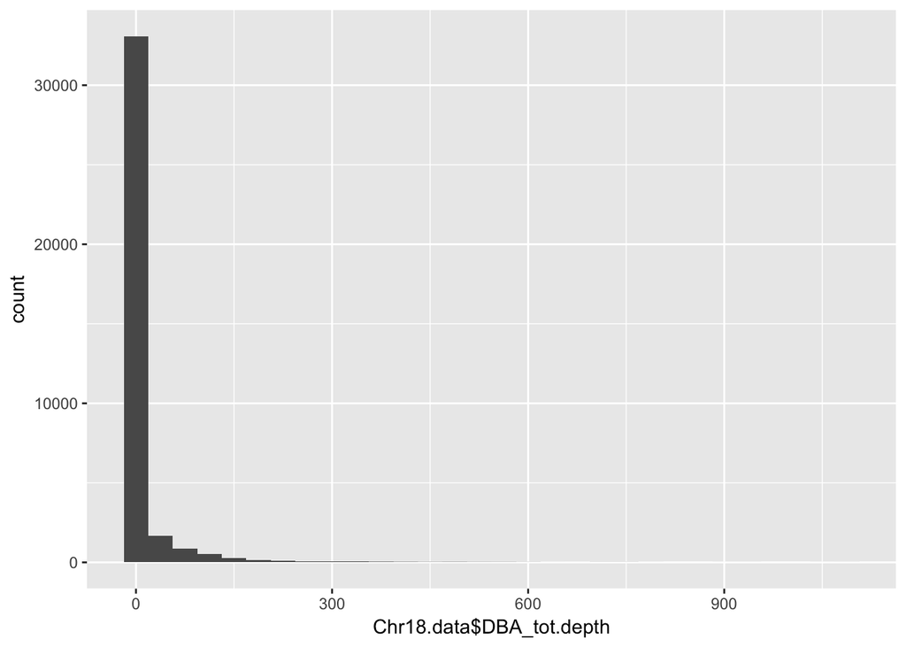

```r
qplot(Chr18.data$DBA_tot.depth, geom="histogram")
```

#### Sequencing depth: DBA, focused

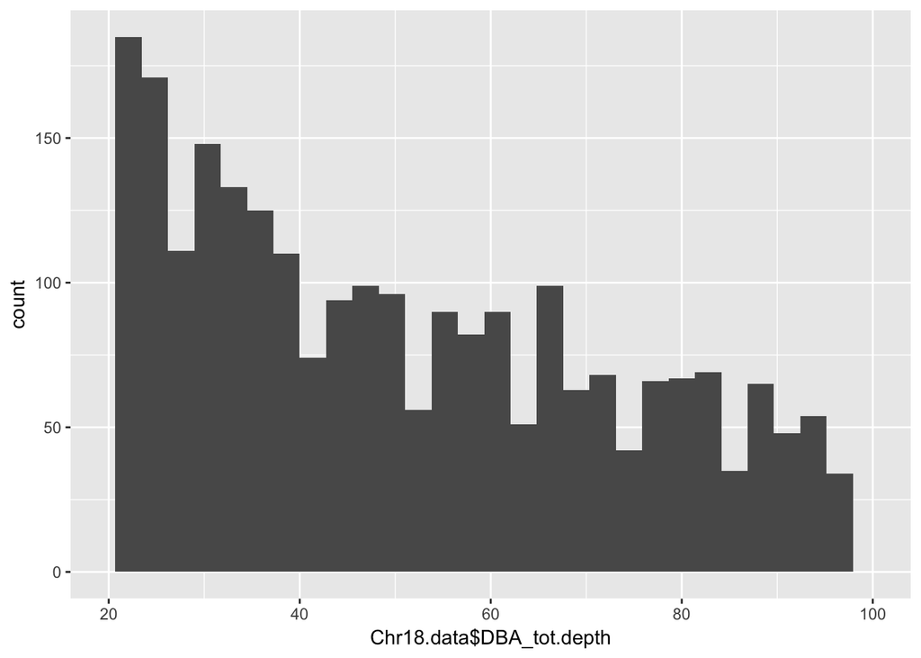

```r
qplot(Chr18.data$DBA_tot.depth, geom="histogram", xlim=c(20, 100))
```

#### Sequencing depth: Chr18, focused

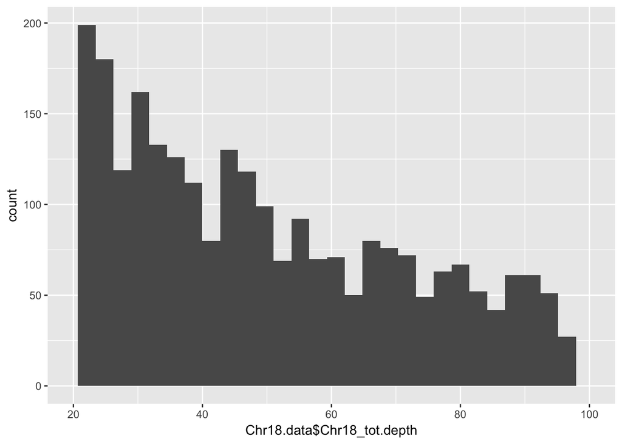

```r
qplot(Chr18.data$Chr18_tot.depth, geom="histogram", xlim=c(20, 100))
```

### Scatterplot of DBA and Chr18 sequencing depths (DP)

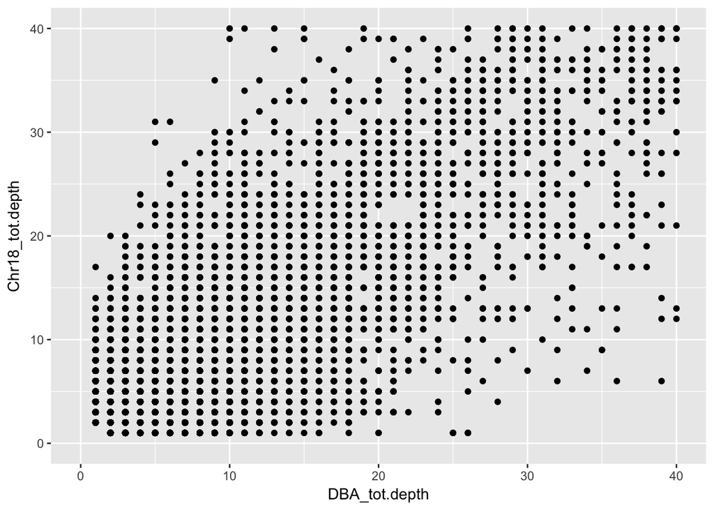

```r
plot1 <- ggplot(Chr18.data, aes(DBA_tot.depth, Chr18_tot.depth))
plot1 + geom_point() + xlim(0,40) + ylim(0,40)
```

### Hmmm…Below 20 reads it gets a little iffy.

### Histogram of QUAL scores:

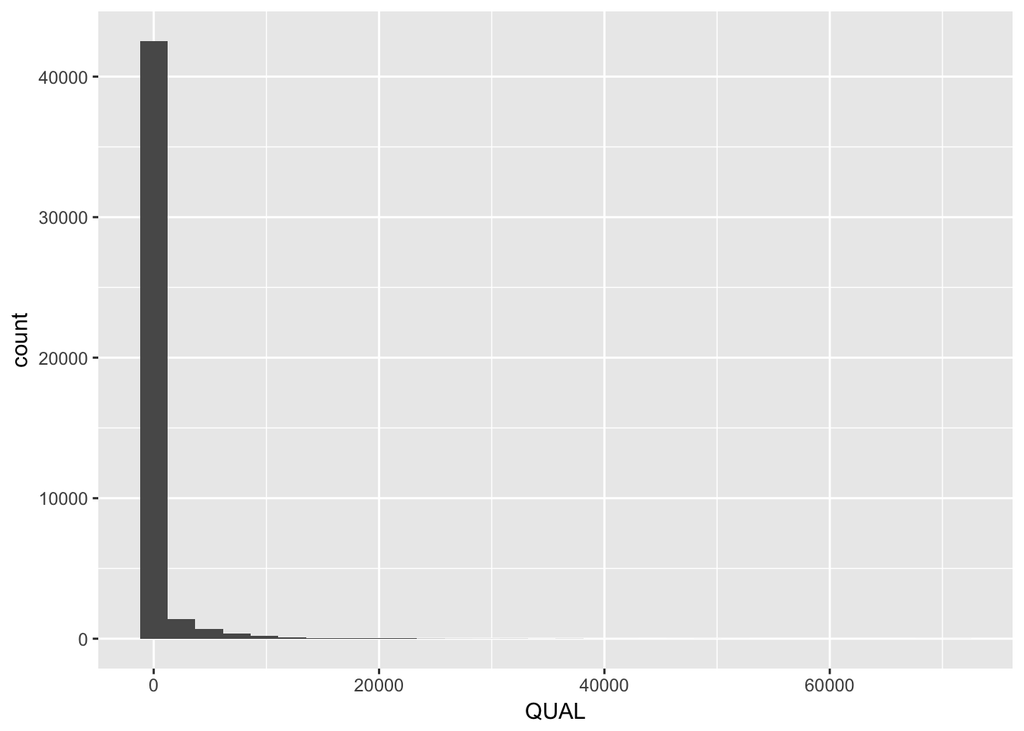

```r
# histogram of low scores
plot2 <- ggplot(Chr18.data, aes(QUAL)) + geom_histogram()
plot2
```

### Well, that’s something. Let’s try again.

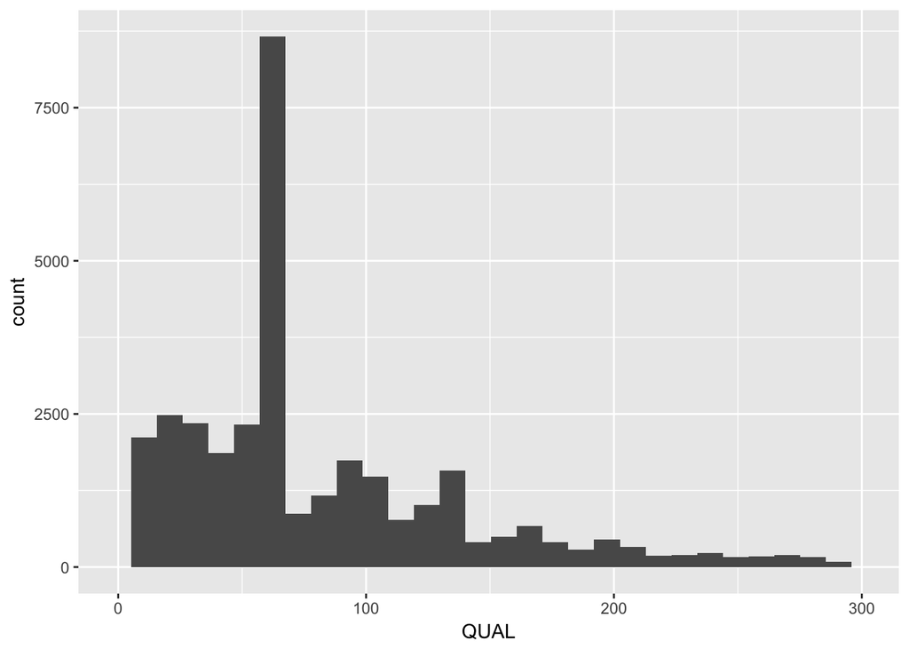

```r
# histogram of low scores
plot3 <- ggplot(Chr18.data, aes(QUAL)) + geom_histogram() + xlim(-1, 300)
plot3
```

### Kinda weird that there is a spike at QUAL ~ 60, similar to what was seen in Chr2 data. I don’t understand why this is happening.

### Subset Chr18.data QUAL > 40

```r
# subset data keeping only SNPs with quality scores greater than or equal to 40
Chr18.Q40.data <- subset(Chr18.data, QUAL >= 40)
```

### Replot scatterplot of read depths on Q40 dataset:

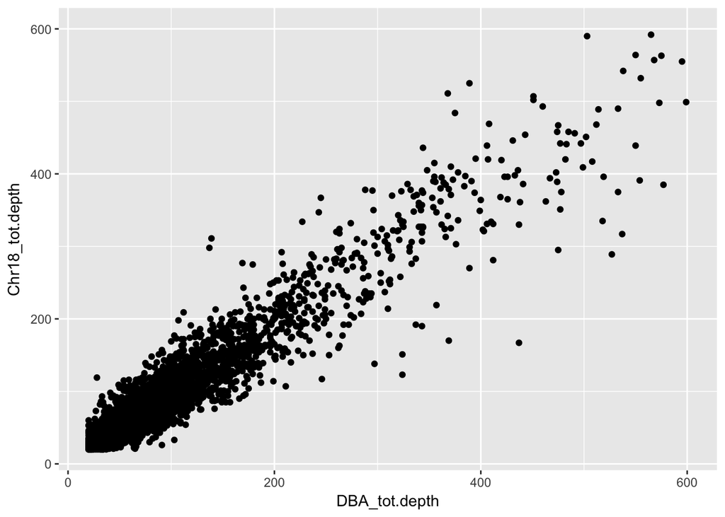

```r
plot4 <- ggplot(Chr18.Q40.data, aes(DBA_tot.depth, Chr18_tot.depth))
plot4 + geom_point() + xlim(20, 600) + ylim(20, 600)
```

### Let’s make a table!

```r
# count the numbers common and unique to each genotype
ftable(Chr18.Q40.data[,c("DBA_gt","Chr18_gt")])
```

```
##        Chr18_gt  0/0  0/1  0/2  0/3  1/1  1/2  1/3  2/2  3/3   NA
## DBA_gt
## 0/0                0  169    0    0  283    7    0    0    0    0
## 0/1              548  655    6    0  576   24    0   15    0  290
## 0/2                0    3    0    0   11    2    3    0    0    0
## 0/3                0    0    0    0    0    1    0    0    0    0
## 1/1             1866  666   13    0 9348   72    0   31    0 8639
## 1/2               29   21    1    2   77   76    3    5    1   70
## 1/3                0    0    2    0    0    2    0    0    0    0
## 2/2                0   12    0    0   61    3    2    0    0    0
## 2/3                0    1    0    0    0    0    0    0    0    0
## 3/3                0    0    0    0    0    3    0    0    0    0
## NA                 0  175    0    0 6206   41    0    0    0    0
```

### Legend: 0=reference allele; 1=first alt. allele; 2=second alt. allele; 3=third alt.allele. Therefore, 0/1=a conventional heterozygote.

### The first thing to look at would be DBA–>0/0 (wild type) and Chr2–>1/1 (homozygous mutant)

### Subset DBA_gt ==0/0 & Chr2_gt==1/1

```r
Chr18.0011.data <- subset(Chr18.Q40.data, (DBA_gt=="0/0" & Chr18_gt == "1/1"))
```

### Make it a little more user-friendly

```r
library(dplyr)
Chr18.0011.tidy.data <-select(Chr18.0011.data, -ID, -FILTER, -INFO, -FORMAT, -DBA, -Chr18)
```

### Plot Chr18 congenic-specific SNPs (Chr18_gt==1/1) to define introgressed region

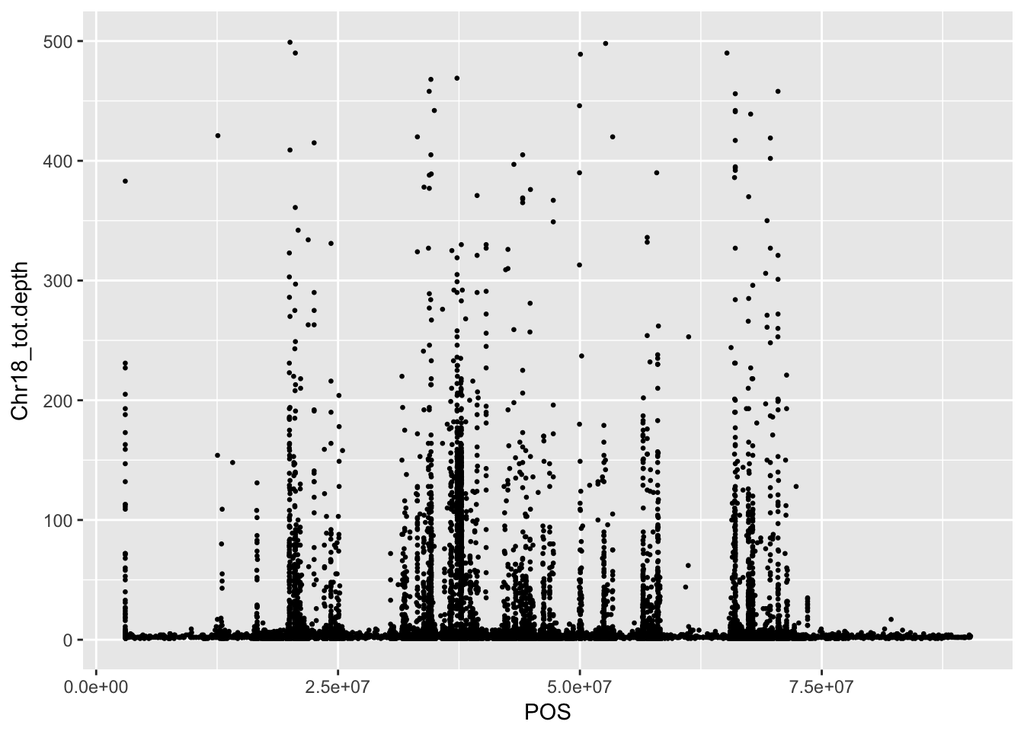

```r
library(ggplot2)
###subset Chr18_gt=="1/1"
Chr18.XX11.data <- subset(Chr18.Q40.data, Chr18_gt=="1/1")
###plot these SNPs using total depth on y-axis and position on x-axis
plot.snps <- ggplot(Chr18.XX11.data , aes(x=POS, y=Chr18_tot.depth)) + geom_point(size = 0.5) + ylim(0,500)
plot.snps
```

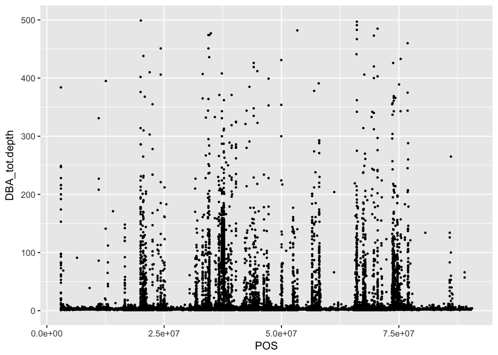

```r
###subset DBA_gt=="1/1"
Chr18.11XX.data <- subset(Chr18.Q40.data, DBA_gt=="1/1")
###plot these SNPs using total depth on y-axis and position on x-axis
plot.D2.snps <- ggplot(Chr18.11XX.data , aes(x=POS, y=DBA_tot.depth)) + geom_point(size = 0.5) + ylim(0,500)
plot.D2.snps
```

### It looks like the introgressed region probably does not include Epg5, unfortunately.

#### No great luck with the Chr18_gt == “1/1”

#### It could be that distal Chr18 is heterozygous in the mouse sent to UCLA. Worth checking.

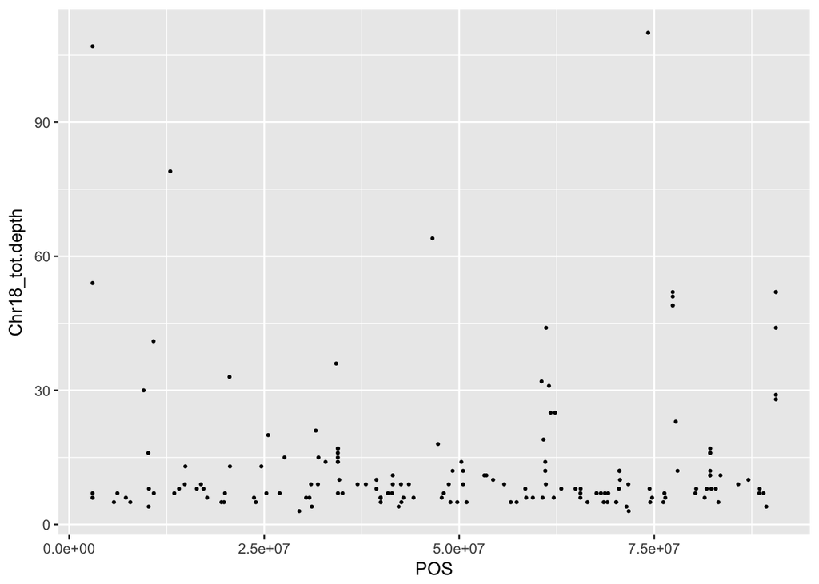

```r
#Subset DBA_gt == "0/0" & Chr18_gt == "0/1"
Chr18.0001.data <- subset(Chr18.Q40.data, (DBA_gt=="0/0" & Chr18_gt=="0/1"))
plot.Chr18.het <- ggplot(Chr18.0001.data, aes(x=POS, y=Chr18_tot.depth)) + geom_point(size=0.5)
plot.Chr18.het
```

### Try to define more carefully the boundaries of introgressed region of Chr18 congenic.

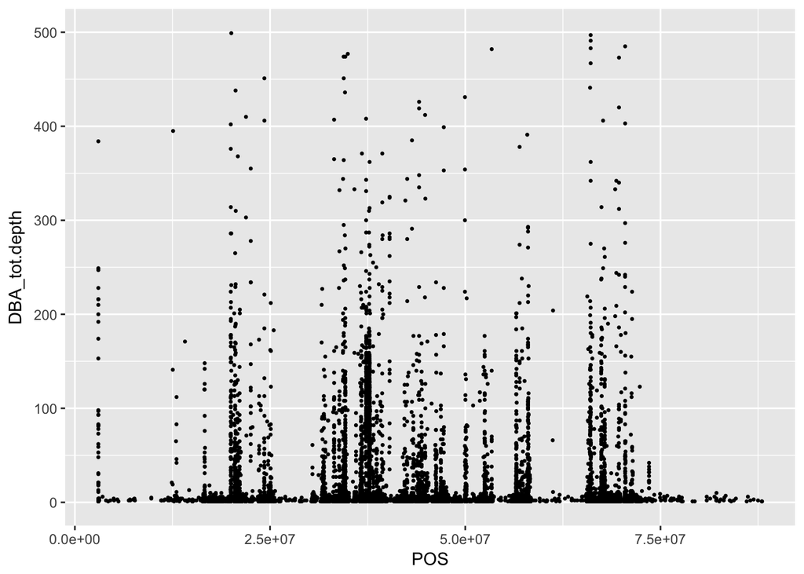

```r
# Subset DBA_gt=="1/1" & Chr18_gt=="1/1"
Chr18.1111.data <- subset(Chr18.Q40.data, (DBA_gt=="1/1" & Chr18_gt=="1/1"))
plot.1111.data <- ggplot(Chr18.1111.data, aes(x=POS, y=DBA_tot.depth)) + geom_point(size = 0.5) + ylim(0, 500)
plot.1111.data
```

#### The above graph confirms that the introgressed region ends at chr18:73533520 (which unfortunately does not include Epg5)